# Case study: How does a bike-share navigate speedy success?

## Scenario

You are a junior data analyst working on the marketing analyst team at Cyclistic, a bike-share company in Chicago. The director of marketing believes the company’s future success depends on maximizing the number of annual memberships. Therefore, your team wants to understand how casual riders and annual members use Cyclistic bikes dirently. From these insights, your team will design a new marketing strategy to convert casual riders into annual members. But first, Cyclistic executives must approve your recommendations, so they must be backed up with compelling data insights and professional data visualizations.

## Characters and teams

- **Cyclistic:** A bike-share program that features more than 5,800 bicycles and 600 docking stations. Cyclistic sets itself apart by also offering reclining bikes, hand tricycles, and cargo bikes, making bike-share more inclusive to people with disabilities and riders who can’t use a standard two-wheeled bike. The majority of riders opt for traditional bikes; about 8% of riders use the assistive options. Cyclistic users are more likely to ride for leisure, but about 30% use the bikes to commute to work each day.
- **Lily Moreno:** The director of marketing and your manager. Moreno is responsible for the development of campaigns and initiatives to promote the bike-share program. These may include email, social media, and other channels.
- **Cyclistic marketing analytics team:** A team of data analysts who are responsible for collecting, analyzing, and reporting data that helps guide Cyclistic marketing strategy. You joined this team six months ago and have been busy learning about Cyclistic’s mission and business goals—as well as how you, as a junior data analyst, can help Cyclistic achieve them.
- **Cyclistic executive team:** The notoriously detail-oriented executive team will decide whether to approve the recommended marketing program.

## About the Company

In 2016, Cyclistic launched a successful bike-share offering. Since then, the program has grown to a fleet of 5,824 bicycles that are geotracked and locked into a network of 692 stations across Chicago. The bikes can be unlocked from one station and returned to any other station in the system anytime.

Until now, Cyclistic’s marketing strategy relied on building general awareness and appealing to broad consumer segments. One approach that helped make these things possible was the flexibility of its pricing plans: single-ride passes, full-day passes, and annual memberships. Customers who purchase single-ride or full-day passes are referred to as casual riders. Customers who purchase annual memberships are Cyclistic members. Cyclistic’s finance analysts have concluded that annual members are much more profitable than casual riders. Although the pricing flexibility helps Cyclistic attract more customers, Moreno believes that maximizing the number of annual members will be key to future growth. Rather than creating a marketing campaign that targets all-new customers, Moreno believes there is a solid opportunity to convert casual riders into members. She notes that casual riders are already aware of the Cyclistic program and have chosen Cyclistic for their mobility needs.

Moreno has set a clear goal: Design marketing strategies aimed at converting casual riders into annual members. In order to do that, however, the team needs to better understand how annual members and casual riders differ, why casual riders would buy a membership, and how digital media could affect their marketing tactics. Moreno and her team are interested in analyzing the Cyclistic historical bike trip data to identify trends.

## Ask

Moreno has assigned you the the following question to answer: How do annual members and casual riders use Cyclistic bikes differently?

You will produce a report with the following deliverables:

1. A clear statement of the business task
2. A description of all data sources used
3. Documentation of any cleaning or manipulation of data
4. A summary of your analysis
5. Supporting visualizations and key findings
6. Your top three recommendations based on your analysis

## Prepare

Because Cyclistic is a fictional company there is no “real-world” data however there is data from [Divvy Bikes](https://divvy-tripdata.s3.amazonaws.com/index.html) made available by Motivate International Inc. under this [licensce](https://divvybikes.com/data-license-agreement). This dataset has the ride information going back to 2013, however it was split by quarter till 2020 after which it was split my month. In order to ensure that data is consitent I would like to combine the last 12 months, June 2023 - May 2024 into one large data set to analyze.

This is first party data collected directly from the company saved in a CSV format. In order to conduct an analysis in R we need to import the CSV files into one dataframe. Doing so will allow for us to use R libraries in order to clean, analyze and plot the data.

## Process

We have data from the last 12 months of Cyclistic trip data. First we need to load the data and to make this cleaner I want to load all 12 months of data into one data frame.

```r
raw_data <- list.files(path = "ride_data",  # Identify all CSV files
                       pattern = "*.csv", full.names = TRUE) %>%
  lapply(read_csv) %>%                              # Store all files in list
  bind_rows                                         # Combine data sets into one data set
ride_data <- raw_data                               # Save copy that will be manipulated
raw_data
```

| ride_id | rideable_type | started_at | ended_at | start_station_name | start_station_id | end_station_name | end_station_id | start_lat | start_lng | end_lat | end_lng | member_casual |
| --- | --- | --- | --- | --- | --- | --- | --- | --- | --- | --- | --- | --- |
| 6F1682AC40EB6F71 | electric_bike | 2023-06-05 13:34:12 | 2023-06-05 14:31:56 | NA | NA | NA | NA | 41.91000 | -87.69000 | 41.91000 | -87.70000 | member |
| 622A1686D64948EB | electric_bike | 2023-06-05 01:30:22 | 2023-06-05 01:33:06 | NA | NA | NA | NA | 41.94000 | -87.65000 | 41.94000 | -87.65000 | member |
| 3C88859D926253B4 | electric_bike | 2023-06-20 18:15:49 | 2023-06-20 18:32:05 | NA | NA | NA | NA | 41.95000 | -87.68000 | 41.92000 | -87.63000 | member |
| EAD8A5E0259DEC88 | electric_bike | 2023-06-19 14:56:00 | 2023-06-19 15:00:35 | NA | NA | NA | NA | 41.99000 | -87.65000 | 41.98000 | -87.66000 | member |
| 5A36F21930D6A55C | electric_bike | 2023-06-19 15:03:34 | 2023-06-19 15:07:16 | NA | NA | NA | NA | 41.98000 | -87.66000 | 41.99000 | -87.65000 | member |
| CF682EA7D0F961DB | electric_bike | 2023-06-09 21:30:25 | 2023-06-09 21:49:52 | NA | NA | NA | NA | 41.99000 | -87.68000 | 41.94000 | -87.65000 | member |
| 4910FBB710157754 | electric_bike | 2023-06-03 13:34:09 | 2023-06-03 13:34:28 | NA | NA | NA | NA | 41.88000 | -87.62000 | 41.88000 | -87.62000 | member |
| EA19D850A42F56D8 | electric_bike | 2023-06-03 13:34:46 | 2023-06-03 13:35:00 | NA | NA | NA | NA | 41.88000 | -87.62000 | 41.88000 | -87.62000 | member |
| E68F43784662A2D0 | electric_bike | 2023-06-02 22:27:35 | 2023-06-02 22:35:26 | NA | NA | NA | NA | 41.95000 | -87.64000 | 41.95000 | -87.65000 | member |
| 5A013E29CC001611 | electric_bike | 2023-06-02 21:18:31 | 2023-06-03 01:27:19 | NA | NA | NA | NA | 41.87000 | -87.63000 | 41.89000 | -87.63000 | member |

[output cut: 990 more lines]

Now let us get a glimpse of our data.

```r
names(ride_data)
```

```
 [1] "ride_id"            "rideable_type"      "started_at"         "ended_at"           "start_station_name" "start_station_id"   "end_station_name"   "end_station_id"     "start_lat"
[10] "start_lng"          "end_lat"            "end_lng"            "member_casual"
```

```r
glimpse(ride_data)
```

```
Rows: 5,743,278
Columns: 13
$ ride_id            <chr> "6F1682AC40EB6F71", "622A1686D64948EB", "3C88859D926253B4", "EAD8A5E0259DEC88", "5A36F21930D6A55C", "CF682EA7D0F961DB", "4910FBB710157754", "EA19D850A42F56D8", "E68F43784662A2D…
$ rideable_type      <chr> "electric_bike", "electric_bike", "electric_bike", "electric_bike", "electric_bike", "electric_bike", "electric_bike", "electric_bike", "electric_bike", "electric_bike", "elect…
$ started_at         <dttm> 2023-06-05 13:34:12, 2023-06-05 01:30:22, 2023-06-20 18:15:49, 2023-06-19 14:56:00, 2023-06-19 15:03:34, 2023-06-09 21:30:25, 2023-06-03 13:34:09, 2023-06-03 13:34:46, 2023-06…
$ ended_at           <dttm> 2023-06-05 14:31:56, 2023-06-05 01:33:06, 2023-06-20 18:32:05, 2023-06-19 15:00:35, 2023-06-19 15:07:16, 2023-06-09 21:49:52, 2023-06-03 13:34:28, 2023-06-03 13:35:00, 2023-06…
$ start_station_name <chr> NA, NA, NA, NA, NA, NA, NA, NA, NA, NA, NA, NA, NA, NA, NA, NA, NA, NA, NA, NA, NA, NA, NA, NA, NA, NA, NA, NA, NA, NA, NA, NA, NA, NA, NA, NA, NA, NA, NA, NA, NA, NA, NA, NA, …
$ start_station_id   <chr> NA, NA, NA, NA, NA, NA, NA, NA, NA, NA, NA, NA, NA, NA, NA, NA, NA, NA, NA, NA, NA, NA, NA, NA, NA, NA, NA, NA, NA, NA, NA, NA, NA, NA, NA, NA, NA, NA, NA, NA, NA, NA, NA, NA, …
$ end_station_name   <chr> NA, NA, NA, NA, NA, NA, NA, NA, NA, NA, NA, NA, NA, NA, NA, NA, NA, NA, NA, NA, NA, NA, NA, NA, NA, NA, NA, NA, NA, NA, NA, NA, NA, NA, NA, NA, NA, NA, NA, NA, NA, NA, NA, NA, …
$ end_station_id     <chr> NA, NA, NA, NA, NA, NA, NA, NA, NA, NA, NA, NA, NA, NA, NA, NA, NA, NA, NA, NA, NA, NA, NA, NA, NA, NA, NA, NA, NA, NA, NA, NA, NA, NA, NA, NA, NA, NA, NA, NA, NA, NA, NA, NA, …
$ start_lat          <dbl> 41.91, 41.94, 41.95, 41.99, 41.98, 41.99, 41.88, 41.88, 41.95, 41.87, 41.93, 41.89, 41.96, 41.85, 41.98, 41.90, 41.93, 41.93, 41.95, 41.93, 41.92, 41.80, 41.88, 41.87, 41.95, 4…
$ start_lng          <dbl> -87.69, -87.65, -87.68, -87.65, -87.66, -87.68, -87.62, -87.62, -87.64, -87.63, -87.63, -87.66, -87.66, -87.62, -87.67, -87.68, -87.68, -87.64, -87.66, -87.65, -87.64, -87.59, …
$ end_lat            <dbl> 41.91000, 41.94000, 41.92000, 41.98000, 41.99000, 41.94000, 41.88000, 41.88000, 41.95000, 41.89000, 41.94000, 41.93000, 41.88000, 41.86000, 41.99000, 41.93000, 41.90000, 41.920…
$ end_lng            <dbl> -87.70000, -87.65000, -87.63000, -87.66000, -87.65000, -87.65000, -87.62000, -87.62000, -87.65000, -87.63000, -87.64000, -87.63000, -87.65000, -87.62000, -87.67000, -87.68000, …
$ member_casual      <chr> "member", "member", "member", "member", "member", "member", "member", "member", "member", "member", "member", "member", "member", "member", "member", "member", "member", "membe…
```

First I want to create a column that describes the length of the ride.

```r
ride_data$ride_time <- as.duration(ride_data$started_at %--% ride_data$ended_at)

glimpse(ride_data)
```

```
Rows: 5,743,278
Columns: 14
$ ride_id            <chr> "6F1682AC40EB6F71", "622A1686D64948EB", "3C88859D926253B4", "EAD8A5E0259DEC88", "5A36F21930D6A55C", "CF682EA7D0F961DB", "4910FBB710157754", "EA19D850A42F56D8", "E68F43784662A2D…
$ rideable_type      <chr> "electric_bike", "electric_bike", "electric_bike", "electric_bike", "electric_bike", "electric_bike", "electric_bike", "electric_bike", "electric_bike", "electric_bike", "elect…
$ started_at         <dttm> 2023-06-05 13:34:12, 2023-06-05 01:30:22, 2023-06-20 18:15:49, 2023-06-19 14:56:00, 2023-06-19 15:03:34, 2023-06-09 21:30:25, 2023-06-03 13:34:09, 2023-06-03 13:34:46, 2023-06…
$ ended_at           <dttm> 2023-06-05 14:31:56, 2023-06-05 01:33:06, 2023-06-20 18:32:05, 2023-06-19 15:00:35, 2023-06-19 15:07:16, 2023-06-09 21:49:52, 2023-06-03 13:34:28, 2023-06-03 13:35:00, 2023-06…
$ start_station_name <chr> NA, NA, NA, NA, NA, NA, NA, NA, NA, NA, NA, NA, NA, NA, NA, NA, NA, NA, NA, NA, NA, NA, NA, NA, NA, NA, NA, NA, NA, NA, NA, NA, NA, NA, NA, NA, NA, NA, NA, NA, NA, NA, NA, NA, …
$ start_station_id   <chr> NA, NA, NA, NA, NA, NA, NA, NA, NA, NA, NA, NA, NA, NA, NA, NA, NA, NA, NA, NA, NA, NA, NA, NA, NA, NA, NA, NA, NA, NA, NA, NA, NA, NA, NA, NA, NA, NA, NA, NA, NA, NA, NA, NA, …
$ end_station_name   <chr> NA, NA, NA, NA, NA, NA, NA, NA, NA, NA, NA, NA, NA, NA, NA, NA, NA, NA, NA, NA, NA, NA, NA, NA, NA, NA, NA, NA, NA, NA, NA, NA, NA, NA, NA, NA, NA, NA, NA, NA, NA, NA, NA, NA, …
$ end_station_id     <chr> NA, NA, NA, NA, NA, NA, NA, NA, NA, NA, NA, NA, NA, NA, NA, NA, NA, NA, NA, NA, NA, NA, NA, NA, NA, NA, NA, NA, NA, NA, NA, NA, NA, NA, NA, NA, NA, NA, NA, NA, NA, NA, NA, NA, …
$ start_lat          <dbl> 41.91, 41.94, 41.95, 41.99, 41.98, 41.99, 41.88, 41.88, 41.95, 41.87, 41.93, 41.89, 41.96, 41.85, 41.98, 41.90, 41.93, 41.93, 41.95, 41.93, 41.92, 41.80, 41.88, 41.87, 41.95, 4…
$ start_lng          <dbl> -87.69, -87.65, -87.68, -87.65, -87.66, -87.68, -87.62, -87.62, -87.64, -87.63, -87.63, -87.66, -87.66, -87.62, -87.67, -87.68, -87.68, -87.64, -87.66, -87.65, -87.64, -87.59, …
$ end_lat            <dbl> 41.91000, 41.94000, 41.92000, 41.98000, 41.99000, 41.94000, 41.88000, 41.88000, 41.95000, 41.89000, 41.94000, 41.93000, 41.88000, 41.86000, 41.99000, 41.93000, 41.90000, 41.920…
$ end_lng            <dbl> -87.70000, -87.65000, -87.63000, -87.66000, -87.65000, -87.65000, -87.62000, -87.62000, -87.65000, -87.63000, -87.64000, -87.63000, -87.65000, -87.62000, -87.67000, -87.68000, …
$ member_casual      <chr> "member", "member", "member", "member", "member", "member", "member", "member", "member", "member", "member", "member", "member", "member", "member", "member", "member", "membe…
$ ride_time          <Duration> 3464s (~57.73 minutes), 164s (~2.73 minutes), 976s (~16.27 minutes), 275s (~4.58 minutes), 222s (~3.7 minutes), 1167s (~19.45 minutes), 19s, 14s, 471s (~7.85 minutes), 149…
```

Now I want to get the start month of all rides.

```r
ride_data$month <- format(as.Date(as.Date(ride_data$started_at), format="%d%%Y"), "%m")
ride_data$start_hour <- format(as.POSIXct(ride_data$started_at), format = "%H")

ride_data
```

| ride_id | rideable_type | started_at | ended_at | start_station_name | start_station_id | end_station_name | end_station_id | start_lat | start_lng | end_lat | end_lng | member_casual | ride_time | month | start_hour |
| --- | --- | --- | --- | --- | --- | --- | --- | --- | --- | --- | --- | --- | --- | --- | --- |
| 6F1682AC40EB6F71 | electric_bike | 2023-06-05 13:34:12 | 2023-06-05 14:31:56 | NA | NA | NA | NA | 41.91000 | -87.69000 | 41.91000 | -87.70000 | member | 3464s (~57.73 minutes) | 06 | 13 |
| 622A1686D64948EB | electric_bike | 2023-06-05 01:30:22 | 2023-06-05 01:33:06 | NA | NA | NA | NA | 41.94000 | -87.65000 | 41.94000 | -87.65000 | member | 164s (~2.73 minutes) | 06 | 01 |
| 3C88859D926253B4 | electric_bike | 2023-06-20 18:15:49 | 2023-06-20 18:32:05 | NA | NA | NA | NA | 41.95000 | -87.68000 | 41.92000 | -87.63000 | member | 976s (~16.27 minutes) | 06 | 18 |
| EAD8A5E0259DEC88 | electric_bike | 2023-06-19 14:56:00 | 2023-06-19 15:00:35 | NA | NA | NA | NA | 41.99000 | -87.65000 | 41.98000 | -87.66000 | member | 275s (~4.58 minutes) | 06 | 14 |
| 5A36F21930D6A55C | electric_bike | 2023-06-19 15:03:34 | 2023-06-19 15:07:16 | NA | NA | NA | NA | 41.98000 | -87.66000 | 41.99000 | -87.65000 | member | 222s (~3.7 minutes) | 06 | 15 |
| CF682EA7D0F961DB | electric_bike | 2023-06-09 21:30:25 | 2023-06-09 21:49:52 | NA | NA | NA | NA | 41.99000 | -87.68000 | 41.94000 | -87.65000 | member | 1167s (~19.45 minutes) | 06 | 21 |
| 4910FBB710157754 | electric_bike | 2023-06-03 13:34:09 | 2023-06-03 13:34:28 | NA | NA | NA | NA | 41.88000 | -87.62000 | 41.88000 | -87.62000 | member | 19s | 06 | 13 |
| EA19D850A42F56D8 | electric_bike | 2023-06-03 13:34:46 | 2023-06-03 13:35:00 | NA | NA | NA | NA | 41.88000 | -87.62000 | 41.88000 | -87.62000 | member | 14s | 06 | 13 |
| E68F43784662A2D0 | electric_bike | 2023-06-02 22:27:35 | 2023-06-02 22:35:26 | NA | NA | NA | NA | 41.95000 | -87.64000 | 41.95000 | -87.65000 | member | 471s (~7.85 minutes) | 06 | 22 |
| 5A013E29CC001611 | electric_bike | 2023-06-02 21:18:31 | 2023-06-03 01:27:19 | NA | NA | NA | NA | 41.87000 | -87.63000 | 41.89000 | -87.63000 | member | 14928s (~4.15 hours) | 06 | 21 |

[output cut: 990 more lines]

```r
NA
```

```r
ride_data$weekday <- weekdays(as.Date(ride_data$started_at), abbreviate = TRUE)

head(ride_data)
```

| ride_id | rideable_type | started_at | ended_at | start_station_name | start_station_id | end_station_name | end_station_id | start_lat | start_lng | end_lat | end_lng | member_casual | ride_time | month | start_hour | weekday |
| --- | --- | --- | --- | --- | --- | --- | --- | --- | --- | --- | --- | --- | --- | --- | --- | --- |
| 6F1682AC40EB6F71 | electric_bike | 2023-06-05 13:34:12 | 2023-06-05 14:31:56 | NA | NA | NA | NA | 41.91 | -87.69 | 41.91 | -87.70 | member | 3464s (~57.73 minutes) | 06 | 13 | Mon |
| 622A1686D64948EB | electric_bike | 2023-06-05 01:30:22 | 2023-06-05 01:33:06 | NA | NA | NA | NA | 41.94 | -87.65 | 41.94 | -87.65 | member | 164s (~2.73 minutes) | 06 | 01 | Mon |
| 3C88859D926253B4 | electric_bike | 2023-06-20 18:15:49 | 2023-06-20 18:32:05 | NA | NA | NA | NA | 41.95 | -87.68 | 41.92 | -87.63 | member | 976s (~16.27 minutes) | 06 | 18 | Tue |
| EAD8A5E0259DEC88 | electric_bike | 2023-06-19 14:56:00 | 2023-06-19 15:00:35 | NA | NA | NA | NA | 41.99 | -87.65 | 41.98 | -87.66 | member | 275s (~4.58 minutes) | 06 | 14 | Mon |
| 5A36F21930D6A55C | electric_bike | 2023-06-19 15:03:34 | 2023-06-19 15:07:16 | NA | NA | NA | NA | 41.98 | -87.66 | 41.99 | -87.65 | member | 222s (~3.7 minutes) | 06 | 15 | Mon |
| CF682EA7D0F961DB | electric_bike | 2023-06-09 21:30:25 | 2023-06-09 21:49:52 | NA | NA | NA | NA | 41.99 | -87.68 | 41.94 | -87.65 | member | 1167s (~19.45 minutes) | 06 | 21 | Fri |

It looks like the *start_station_name*, *start_station_id*, *end_station_name*, *end_station_id* don’t have much data, but we have the *start_lat*, *start_lng* and the *end_lat*, *end_lng*. Let us look into the station names and ids further to see if we can omit this information.

```r
ride_data %>%
  drop_na(c("start_station_name", "start_station_id", "end_station_name", "end_station_id"))
```

| ride_id | rideable_type | started_at | ended_at | start_station_name | start_station_id | end_station_name | end_station_id | start_lat | start_lng | end_lat | end_lng | member_casual | ride_time | month | start_hour | weekday |
| --- | --- | --- | --- | --- | --- | --- | --- | --- | --- | --- | --- | --- | --- | --- | --- | --- |
| 055E6783FCD761FD | electric_bike | 2023-06-06 20:58:13 | 2023-06-06 21:04:00 | California Ave & Milwaukee Ave | 13084 | California Ave & Division St | 13256 | 41.92262 | -87.69711 | 41.90303 | -87.69747 | member | 347s (~5.78 minutes) | 06 | 20 | Tue |
| 65BC2A1FC12CFFA4 | classic_bike | 2023-06-28 18:21:26 | 2023-06-28 18:56:06 | Cottage Grove Ave & 51st St | TA1309000067 | Cottage Grove Ave & 51st St | TA1309000067 | 41.80304 | -87.60662 | 41.80304 | -87.60662 | member | 2080s (~34.67 minutes) | 06 | 18 | Wed |
| 4D149B57532FE9C9 | classic_bike | 2023-06-30 09:53:16 | 2023-06-30 09:53:38 | Western Ave & Roscoe St | 15634 | Western Ave & Roscoe St | 15634 | 41.94303 | -87.68729 | 41.94303 | -87.68729 | member | 22s | 06 | 09 | Fri |
| BAE48AFCA5C36414 | classic_bike | 2023-06-21 13:23:57 | 2023-06-21 13:24:16 | Cottage Grove Ave & 51st St | TA1309000067 | Cottage Grove Ave & 51st St | TA1309000067 | 41.80304 | -87.60662 | 41.80304 | -87.60662 | member | 19s | 06 | 13 | Wed |
| E3491C5273700783 | classic_bike | 2023-06-21 13:24:46 | 2023-06-21 13:40:47 | Cottage Grove Ave & 51st St | TA1309000067 | Cottage Grove Ave & 51st St | TA1309000067 | 41.80304 | -87.60662 | 41.80304 | -87.60662 | member | 961s (~16.02 minutes) | 06 | 13 | Wed |
| 4AE5E4B5B30DBFEF | classic_bike | 2023-06-02 23:39:41 | 2023-06-02 23:40:26 | California Ave & Milwaukee Ave | 13084 | California Ave & Milwaukee Ave | 13084 | 41.92269 | -87.69715 | 41.92269 | -87.69715 | member | 45s | 06 | 23 | Fri |
| 206CA7317C7F4D44 | classic_bike | 2023-06-26 13:39:20 | 2023-06-26 13:41:04 | Cottage Grove Ave & 51st St | TA1309000067 | Cottage Grove Ave & 51st St | TA1309000067 | 41.80304 | -87.60662 | 41.80304 | -87.60662 | member | 104s (~1.73 minutes) | 06 | 13 | Mon |
| 1E1BA8971F280144 | classic_bike | 2023-06-30 18:05:47 | 2023-06-30 18:22:26 | Cottage Grove Ave & 51st St | TA1309000067 | Cottage Grove Ave & 51st St | TA1309000067 | 41.80304 | -87.60662 | 41.80304 | -87.60662 | member | 999s (~16.65 minutes) | 06 | 18 | Fri |
| 3CC49A8C761A669B | docked_bike | 2023-06-09 21:54:25 | 2023-06-10 06:31:43 | California Ave & Division St | 13256 | California Ave & Division St | 13256 | 41.90303 | -87.69747 | 41.90303 | -87.69747 | casual | 31038s (~8.62 hours) | 06 | 21 | Fri |
| 2AE37FA54EBBAD96 | electric_bike | 2023-06-16 07:07:08 | 2023-06-16 07:07:33 | Wood St & Chicago Ave | 637 | Wood St & Chicago Ave | 637 | 41.89565 | -87.67214 | 41.89563 | -87.67207 | member | 25s | 06 | 07 | Fri |

[output cut: 990 more lines]

We can see that we lost about 1.5 million rows of data, however there are ~4.3 million rows of data that has the information we need. In this case I will omit the 1.5 million rides without a start and end station since our goal is to determine the riding habits between members and casual riders and we can get trends based on the data we have left.

```r
ride_data <- ride_data %>%
  drop_na(c("start_station_name", "start_station_id", "end_station_name", "end_station_id"))
```

Alternatively if we had a data set with *station_name*, *station_id*, *station_lng*, *station_lat* then we could fill in missing information based on the latitude and longitude.

## Analyze

Let us look at the max, min, and mean of the ride times for both the members and casaul riders to get a better idea of their riding habits.

```r
min(ride_data$ride_time, na.rm = FALSE)
```

```
[1] -3274
```

```r
max(ride_data$ride_time, na.rm = FALSE)
```

```
[1] 669136
```

```r
mean(ride_data$ride_time, na.rm = FALSE)
```

```
[1] 980.7299
```

It looks like our minimum time is negative. Let us look at any *ride_time* that has a negative value.

```r
ride_data[ride_data$ride_time < 0, ] # There are a lot with ride_time = -1
```

| ride_id | rideable_type | started_at | ended_at | start_station_name | start_station_id | end_station_name | end_station_id | start_lat | start_lng | end_lat | end_lng | member_casual | ride_time | month | start_hour | weekday |
| --- | --- | --- | --- | --- | --- | --- | --- | --- | --- | --- | --- | --- | --- | --- | --- | --- |
| FAC4E90497237BD1 | classic_bike | 2023-06-01 16:47:50 | 2023-06-01 16:47:49 | Lincoln Ave & Roscoe St* | chargingstx5 | Lincoln Ave & Roscoe St* | chargingstx5 | 41.94335 | -87.67067 | 41.94335 | -87.67067 | member | -1s | 06 | 16 | Thu |
| 199D68ECEC1DACF3 | electric_bike | 2023-06-10 15:49:14 | 2023-06-10 15:49:13 | Wentworth Ave & Cermak Rd* | chargingstx07 | Wentworth Ave & Cermak Rd* | chargingstx07 | 41.85318 | -87.63185 | 41.85321 | -87.63187 | casual | -1s | 06 | 15 | Sat |
| 0F2C8AC039F63D8F | electric_bike | 2023-06-08 16:31:42 | 2023-06-08 16:31:38 | Broadway & Cornelia Ave | 13278 | Broadway & Cornelia Ave | 13278 | 41.94552 | -87.64647 | 41.94553 | -87.64644 | member | -4s | 06 | 16 | Thu |
| 09632A75482D0DEE | electric_bike | 2023-07-30 01:21:48 | 2023-07-30 01:21:44 | Lincoln Ave & Roscoe St* | chargingstx5 | Lincoln Ave & Roscoe St* | chargingstx5 | 41.94333 | -87.67074 | 41.94332 | -87.67075 | casual | -4s | 07 | 01 | Sun |
| CE965D382AED6196 | electric_bike | 2023-07-20 12:54:28 | 2023-07-20 12:54:27 | California Ave & Marquette Rd | 390 | California Ave & Marquette Rd | 390 | 41.77160 | -87.69334 | 41.77158 | -87.69336 | casual | -1s | 07 | 12 | Thu |
| 68912B520CB9541C | electric_bike | 2023-07-20 11:04:45 | 2023-07-20 11:04:44 | Public Rack - Milwaukee Ave & Higgins Ave | 1121.0 | Public Rack - Milwaukee Ave & Higgins Ave | 1121.0 | 41.96858 | -87.76133 | 41.96860 | -87.76121 | member | -1s | 07 | 11 | Thu |
| 88C6795EB8654AF5 | electric_bike | 2023-08-19 03:01:47 | 2023-08-19 03:00:12 | Southport Ave & Belmont Ave | 13229 | Southport Ave & Belmont Ave | 13229 | 41.93935 | -87.66393 | 41.93948 | -87.66375 | casual | -95s (~-1.58 minutes) | 08 | 03 | Sat |
| 197D33FAF6396DDC | electric_bike | 2023-08-18 16:01:29 | 2023-08-18 16:01:28 | Stockton Dr & Wrightwood Ave | 13276 | Stockton Dr & Wrightwood Ave | 13276 | 41.93129 | -87.63877 | 41.93132 | -87.63874 | casual | -1s | 08 | 16 | Fri |
| 82B071A054A869E0 | electric_bike | 2023-08-19 16:19:27 | 2023-08-19 16:19:25 | Larrabee St & Division St | KA1504000079 | Larrabee St & Division St | KA1504000079 | 41.90357 | -87.64336 | 41.90349 | -87.64335 | member | -2s | 08 | 16 | Sat |
| B4C9ECBF117035CD | classic_bike | 2023-08-12 15:26:17 | 2023-08-12 15:14:41 | Shedd Aquarium | 15544 | Shedd Aquarium | 15544 | 41.86723 | -87.61536 | 41.86723 | -87.61536 | casual | -696s (~-11.6 minutes) | 08 | 15 | Sat |

[output cut: 62 more lines]

```r
ride_data[ride_data$ride_time == - 1,] # These look like mistakes and can be omitted
```

| ride_id | rideable_type | started_at | ended_at | start_station_name | start_station_id | end_station_name | end_station_id | start_lat | start_lng | end_lat | end_lng | member_casual | ride_time | month | start_hour | weekday |
| --- | --- | --- | --- | --- | --- | --- | --- | --- | --- | --- | --- | --- | --- | --- | --- | --- |
| FAC4E90497237BD1 | classic_bike | 2023-06-01 16:47:50 | 2023-06-01 16:47:49 | Lincoln Ave & Roscoe St* | chargingstx5 | Lincoln Ave & Roscoe St* | chargingstx5 | 41.94335 | -87.67067 | 41.94335 | -87.67067 | member | -1s | 06 | 16 | Thu |
| 199D68ECEC1DACF3 | electric_bike | 2023-06-10 15:49:14 | 2023-06-10 15:49:13 | Wentworth Ave & Cermak Rd* | chargingstx07 | Wentworth Ave & Cermak Rd* | chargingstx07 | 41.85318 | -87.63185 | 41.85321 | -87.63187 | casual | -1s | 06 | 15 | Sat |
| CE965D382AED6196 | electric_bike | 2023-07-20 12:54:28 | 2023-07-20 12:54:27 | California Ave & Marquette Rd | 390 | California Ave & Marquette Rd | 390 | 41.77160 | -87.69334 | 41.77158 | -87.69336 | casual | -1s | 07 | 12 | Thu |
| 68912B520CB9541C | electric_bike | 2023-07-20 11:04:45 | 2023-07-20 11:04:44 | Public Rack - Milwaukee Ave & Higgins Ave | 1121.0 | Public Rack - Milwaukee Ave & Higgins Ave | 1121.0 | 41.96858 | -87.76133 | 41.96860 | -87.76121 | member | -1s | 07 | 11 | Thu |
| 197D33FAF6396DDC | electric_bike | 2023-08-18 16:01:29 | 2023-08-18 16:01:28 | Stockton Dr & Wrightwood Ave | 13276 | Stockton Dr & Wrightwood Ave | 13276 | 41.93129 | -87.63877 | 41.93132 | -87.63874 | casual | -1s | 08 | 16 | Fri |
| A46983F7A2B5C09D | electric_bike | 2023-08-30 16:28:09 | 2023-08-30 16:28:08 | Larrabee St & Kingsbury St | TA1306000009 | Larrabee St & Kingsbury St | TA1306000009 | 41.89756 | -87.64325 | 41.89776 | -87.64288 | member | -1s | 08 | 16 | Wed |
| BA2B853114788016 | electric_bike | 2023-08-23 17:19:15 | 2023-08-23 17:19:14 | Canal St & Madison St | 13341 | Canal St & Madison St | 13341 | 41.88201 | -87.63927 | 41.88241 | -87.63977 | casual | -1s | 08 | 17 | Wed |
| 2B0611A87746828A | electric_bike | 2023-09-02 20:24:45 | 2023-09-02 20:24:44 | Green St & Madison St | TA1307000120 | Green St & Madison St | TA1307000120 | 41.88187 | -87.64909 | 41.88186 | -87.64926 | casual | -1s | 09 | 20 | Sat |
| F64E7C8540581F9E | classic_bike | 2023-09-22 13:18:54 | 2023-09-22 13:18:53 | Ravenswood Ave & Lawrence Ave | TA1309000066 | Ravenswood Ave & Lawrence Ave | TA1309000066 | 41.96845 | -87.67423 | 41.96845 | -87.67423 | member | -1s | 09 | 13 | Fri |
| E5381B824D067671 | electric_bike | 2023-10-01 00:15:12 | 2023-10-01 00:15:11 | Leavitt St & Archer Ave | KA1503000068 | Leavitt St & Archer Ave | KA1503000068 | 41.82879 | -87.68064 | 41.82879 | -87.68060 | casual | -1s | 10 | 00 | Sun |

[output cut: 21 more lines]

We will omit any rows of data with *ride_time* < 0 since there can be any number of reasons why this happened and without being able to converse with the team directly there is no guarantee that an assumption is correct.

```r
ride_data <- subset(ride_data, ride_time > 0)

glimpse(ride_data)
```

```
Rows: 4,314,230
Columns: 17
$ ride_id            <chr> "055E6783FCD761FD", "65BC2A1FC12CFFA4", "4D149B57532FE9C9", "BAE48AFCA5C36414", "E3491C5273700783", "4AE5E4B5B30DBFEF", "206CA7317C7F4D44", "1E1BA8971F280144", "3CC49A8C761A669…
$ rideable_type      <chr> "electric_bike", "classic_bike", "classic_bike", "classic_bike", "classic_bike", "classic_bike", "classic_bike", "classic_bike", "docked_bike", "electric_bike", "classic_bike",…
$ started_at         <dttm> 2023-06-06 20:58:13, 2023-06-28 18:21:26, 2023-06-30 09:53:16, 2023-06-21 13:23:57, 2023-06-21 13:24:46, 2023-06-02 23:39:41, 2023-06-26 13:39:20, 2023-06-30 18:05:47, 2023-06…
$ ended_at           <dttm> 2023-06-06 21:04:00, 2023-06-28 18:56:06, 2023-06-30 09:53:38, 2023-06-21 13:24:16, 2023-06-21 13:40:47, 2023-06-02 23:40:26, 2023-06-26 13:41:04, 2023-06-30 18:22:26, 2023-06…
$ start_station_name <chr> "California Ave & Milwaukee Ave", "Cottage Grove Ave & 51st St", "Western Ave & Roscoe St", "Cottage Grove Ave & 51st St", "Cottage Grove Ave & 51st St", "California Ave & Milw…
$ start_station_id   <chr> "13084", "TA1309000067", "15634", "TA1309000067", "TA1309000067", "13084", "TA1309000067", "TA1309000067", "13256", "637", "13084", "13256", "13084", "13084", "13256", "13256",…
$ end_station_name   <chr> "California Ave & Division St", "Cottage Grove Ave & 51st St", "Western Ave & Roscoe St", "Cottage Grove Ave & 51st St", "Cottage Grove Ave & 51st St", "California Ave & Milwau…
$ end_station_id     <chr> "13256", "TA1309000067", "15634", "TA1309000067", "TA1309000067", "13084", "TA1309000067", "TA1309000067", "13256", "637", "13256", "13256", "13084", "13084", "13256", "13256",…
$ start_lat          <dbl> 41.92262, 41.80304, 41.94303, 41.80304, 41.80304, 41.92269, 41.80304, 41.80304, 41.90303, 41.89565, 41.92269, 41.90303, 41.92269, 41.92269, 41.90301, 41.90303, 41.90303, 41.903…
$ start_lng          <dbl> -87.69711, -87.60662, -87.68729, -87.60662, -87.60662, -87.69715, -87.60662, -87.60662, -87.69747, -87.67214, -87.69715, -87.69747, -87.69717, -87.69715, -87.69754, -87.69747, …
$ end_lat            <dbl> 41.90303, 41.80304, 41.94303, 41.80304, 41.80304, 41.92269, 41.80304, 41.80304, 41.90303, 41.89563, 41.90303, 41.90303, 41.92269, 41.92269, 41.90303, 41.90303, 41.90303, 41.903…
$ end_lng            <dbl> -87.69747, -87.60662, -87.68729, -87.60662, -87.60662, -87.69715, -87.60662, -87.60662, -87.69747, -87.67207, -87.69747, -87.69747, -87.69715, -87.69715, -87.69747, -87.69747, …
$ member_casual      <chr> "member", "member", "member", "member", "member", "member", "member", "member", "casual", "member", "member", "casual", "member", "member", "member", "member", "casual", "membe…
$ ride_time          <Duration> 347s (~5.78 minutes), 2080s (~34.67 minutes), 22s, 19s, 961s (~16.02 minutes), 45s, 104s (~1.73 minutes), 999s (~16.65 minutes), 31038s (~8.62 hours), 25s, 542s (~9.03 min…
$ month              <chr> "06", "06", "06", "06", "06", "06", "06", "06", "06", "06", "06", "06", "06", "06", "06", "06", "06", "06", "06", "06", "06", "06", "06", "06", "06", "06", "06", "06", "06", "0…
$ start_hour         <chr> "20", "18", "09", "13", "13", "23", "13", "18", "21", "07", "17", "12", "13", "23", "20", "13", "09", "12", "19", "14", "17", "06", "20", "23", "19", "07", "16", "15", "12", "1…
$ weekday            <chr> "Tue", "Wed", "Fri", "Wed", "Wed", "Fri", "Mon", "Fri", "Fri", "Fri", "Mon", "Sun", "Sun", "Sat", "Sun", "Sun", "Mon", "Wed", "Tue", "Sun", "Sun", "Sat", "Fri", "Fri", "Sun", "…
```

Now I want to create two separate dataframes, one for members and one for casual riders.

```r
member_data <- filter(ride_data, member_casual == 'member')
glimpse(member_data)
```

```
Rows: 2,799,250
Columns: 17
$ ride_id            <chr> "055E6783FCD761FD", "65BC2A1FC12CFFA4", "4D149B57532FE9C9", "BAE48AFCA5C36414", "E3491C5273700783", "4AE5E4B5B30DBFEF", "206CA7317C7F4D44", "1E1BA8971F280144", "2AE37FA54EBBAD9…
$ rideable_type      <chr> "electric_bike", "classic_bike", "classic_bike", "classic_bike", "classic_bike", "classic_bike", "classic_bike", "classic_bike", "electric_bike", "classic_bike", "electric_bike…
$ started_at         <dttm> 2023-06-06 20:58:13, 2023-06-28 18:21:26, 2023-06-30 09:53:16, 2023-06-21 13:23:57, 2023-06-21 13:24:46, 2023-06-02 23:39:41, 2023-06-26 13:39:20, 2023-06-30 18:05:47, 2023-06…
$ ended_at           <dttm> 2023-06-06 21:04:00, 2023-06-28 18:56:06, 2023-06-30 09:53:38, 2023-06-21 13:24:16, 2023-06-21 13:40:47, 2023-06-02 23:40:26, 2023-06-26 13:41:04, 2023-06-30 18:22:26, 2023-06…
$ start_station_name <chr> "California Ave & Milwaukee Ave", "Cottage Grove Ave & 51st St", "Western Ave & Roscoe St", "Cottage Grove Ave & 51st St", "Cottage Grove Ave & 51st St", "California Ave & Milw…
$ start_station_id   <chr> "13084", "TA1309000067", "15634", "TA1309000067", "TA1309000067", "13084", "TA1309000067", "TA1309000067", "637", "13084", "13084", "13084", "13256", "13256", "13256", "13084",…
$ end_station_name   <chr> "California Ave & Division St", "Cottage Grove Ave & 51st St", "Western Ave & Roscoe St", "Cottage Grove Ave & 51st St", "Cottage Grove Ave & 51st St", "California Ave & Milwau…
$ end_station_id     <chr> "13256", "TA1309000067", "15634", "TA1309000067", "TA1309000067", "13084", "TA1309000067", "TA1309000067", "637", "13256", "13084", "13084", "13256", "13256", "13256", "13256",…
$ start_lat          <dbl> 41.92262, 41.80304, 41.94303, 41.80304, 41.80304, 41.92269, 41.80304, 41.80304, 41.89565, 41.92269, 41.92269, 41.92269, 41.90301, 41.90303, 41.90303, 41.92269, 41.90303, 41.803…
$ start_lng          <dbl> -87.69711, -87.60662, -87.68729, -87.60662, -87.60662, -87.69715, -87.60662, -87.60662, -87.67214, -87.69715, -87.69717, -87.69715, -87.69754, -87.69747, -87.69747, -87.69715, …
$ end_lat            <dbl> 41.90303, 41.80304, 41.94303, 41.80304, 41.80304, 41.92269, 41.80304, 41.80304, 41.89563, 41.90303, 41.92269, 41.92269, 41.90303, 41.90303, 41.90303, 41.90303, 41.92269, 41.791…
$ end_lng            <dbl> -87.69747, -87.60662, -87.68729, -87.60662, -87.60662, -87.69715, -87.60662, -87.60662, -87.67207, -87.69747, -87.69715, -87.69715, -87.69747, -87.69747, -87.69747, -87.69747, …
$ member_casual      <chr> "member", "member", "member", "member", "member", "member", "member", "member", "member", "member", "member", "member", "member", "member", "member", "member", "member", "membe…
$ ride_time          <Duration> 347s (~5.78 minutes), 2080s (~34.67 minutes), 22s, 19s, 961s (~16.02 minutes), 45s, 104s (~1.73 minutes), 999s (~16.65 minutes), 25s, 542s (~9.03 minutes), 46s, 37s, 923s …
$ month              <chr> "06", "06", "06", "06", "06", "06", "06", "06", "06", "06", "06", "06", "06", "06", "06", "06", "06", "06", "06", "06", "06", "06", "06", "06", "06", "06", "06", "06", "06", "0…
$ start_hour         <chr> "20", "18", "09", "13", "13", "23", "13", "18", "07", "17", "13", "23", "20", "13", "12", "14", "17", "06", "20", "23", "19", "07", "16", "15", "12", "15", "18", "22", "19", "1…
$ weekday            <chr> "Tue", "Wed", "Fri", "Wed", "Wed", "Fri", "Mon", "Fri", "Fri", "Mon", "Sun", "Sat", "Sun", "Sun", "Wed", "Sun", "Sun", "Sat", "Fri", "Fri", "Sun", "Sun", "Sat", "Mon", "Mon", "…
```

```r
casual_data <- filter(ride_data, member_casual == 'casual')
glimpse(casual_data)
```

```
Rows: 1,514,980
Columns: 17
$ ride_id            <chr> "3CC49A8C761A669B", "928BC74967190966", "C7A10EF1C29DFEDC", "AB91410999F7DB52", "B5A7968E91EBE668", "0100C17DD00FC1EC", "6B3FDE81CC3F4CD2", "D26E43D68D5A1E0F", "AC1073185AE164F…
$ rideable_type      <chr> "docked_bike", "docked_bike", "docked_bike", "docked_bike", "classic_bike", "electric_bike", "classic_bike", "classic_bike", "classic_bike", "classic_bike", "electric_bike", "c…
$ started_at         <dttm> 2023-06-09 21:54:25, 2023-06-18 12:16:43, 2023-06-19 09:03:56, 2023-06-20 19:57:51, 2023-06-13 07:40:23, 2023-06-21 17:44:16, 2023-06-30 16:23:05, 2023-06-10 14:53:35, 2023-06…
$ ended_at           <dttm> 2023-06-10 06:31:43, 2023-06-18 12:46:23, 2023-06-19 09:06:17, 2023-06-20 21:40:08, 2023-06-13 08:24:35, 2023-06-21 17:46:14, 2023-06-30 16:25:39, 2023-06-10 14:59:45, 2023-06…
$ start_station_name <chr> "California Ave & Division St", "California Ave & Division St", "California Ave & Division St", "Western Ave & Roscoe St", "Halsted St & 47th Pl", "Dayton St & North Ave", "Wel…
$ start_station_id   <chr> "13256", "13256", "13256", "15634", "KA1503000051", "13058", "22001", "22001", "13058", "22001", "22001", "SL-012", "SL-012", "chargingstx3", "520", "520", "22001", "22001", "c…
$ end_station_name   <chr> "California Ave & Division St", "California Ave & Division St", "California Ave & Division St", "Western Ave & Roscoe St", "Clark St & Randolph St", "Sheffield Ave & Kingsbury …
$ end_station_id     <chr> "13256", "13256", "13256", "15634", "TA1305000030", "13154", "KA1504000135", "KA1504000135", "13154", "KA1504000135", "KA1504000135", "TA1305000009", "KA1504000135", "TA1307000…
$ start_lat          <dbl> 41.90303, 41.90303, 41.90303, 41.94303, 41.80813, 41.91064, 41.89738, 41.89738, 41.91058, 41.89738, 41.89757, 41.86038, 41.86038, 41.88357, 42.01597, 42.01600, 41.89738, 41.897…
$ start_lng          <dbl> -87.69747, -87.69747, -87.69747, -87.68729, -87.64562, -87.64940, -87.63442, -87.63442, -87.64942, -87.63442, -87.63432, -87.62581, -87.62585, -87.64853, -87.66857, -87.66874, …
$ end_lat            <dbl> 41.90303, 41.90303, 41.90303, 41.94303, 41.88458, 41.91052, 41.90322, 41.90322, 41.91052, 41.90322, 41.90322, 41.87593, 41.90322, 41.88991, 41.98404, 41.96159, 41.89662, 41.896…
$ end_lng            <dbl> -87.69747, -87.69747, -87.69747, -87.68729, -87.63189, -87.65311, -87.63432, -87.63432, -87.65311, -87.63432, -87.63432, -87.63058, -87.63432, -87.63427, -87.66027, -87.66604, …
$ member_casual      <chr> "casual", "casual", "casual", "casual", "casual", "casual", "casual", "casual", "casual", "casual", "casual", "casual", "casual", "casual", "casual", "casual", "casual", "casua…
$ ride_time          <Duration> 31038s (~8.62 hours), 1780s (~29.67 minutes), 141s (~2.35 minutes), 6137s (~1.7 hours), 2652s (~44.2 minutes), 118s (~1.97 minutes), 154s (~2.57 minutes), 370s (~6.17 minu…
$ month              <chr> "06", "06", "06", "06", "06", "06", "06", "06", "06", "06", "06", "06", "06", "06", "06", "06", "06", "06", "06", "06", "06", "06", "06", "06", "06", "06", "06", "06", "06", "0…
$ start_hour         <chr> "21", "12", "09", "19", "07", "17", "16", "14", "17", "17", "08", "15", "16", "23", "08", "18", "10", "17", "22", "07", "12", "14", "20", "10", "22", "16", "16", "11", "11", "1…
$ weekday            <chr> "Fri", "Sun", "Mon", "Tue", "Tue", "Wed", "Fri", "Sat", "Sat", "Sat", "Sat", "Sat", "Thu", "Sun", "Wed", "Mon", "Fri", "Fri", "Fri", "Fri", "Sat", "Thu", "Wed", "Mon", "Fri", "…
```

Now let us look at the specific min, max, and mean of *ride_time* and the mode of *weekday* for both members and casual riders.

```r
find_mode <- function(x) {
  u <- unique(x)
  tab <- tabulate(match(x, u))
  u[tab == max(tab)]
}
```

```r
min(member_data$ride_time, na.rm = FALSE)
```

```
[1] 1
```

```r
max(member_data$ride_time, na.rm = FALSE)
```

```
[1] 89859
```

```r
mean(member_data$ride_time, na.rm = FALSE)
```

```
[1] 745.7826
```

```r
find_mode(member_data$weekday)
```

```
[1] "Thu"
```

```r
min(casual_data$ride_time, na.rm = FALSE)
```

```
[1] 1
```

```r
max(casual_data$ride_time, na.rm = FALSE)
```

```
[1] 669136
```

```r
mean(casual_data$ride_time, na.rm = FALSE)
```

```
[1] 1415.332
```

```r
find_mode(casual_data$weekday)
```

```
[1] "Sat"
```

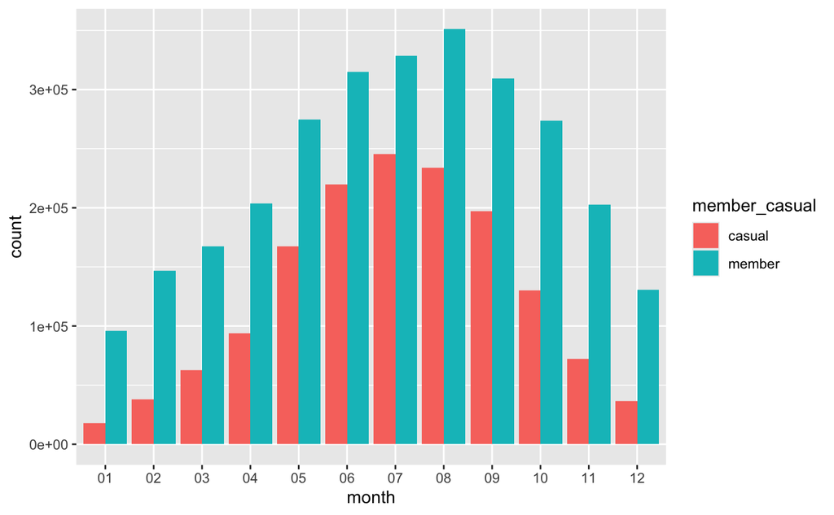

```r
ggplot(
  data = ride_data,
  mapping = aes(x = month, fill = member_casual)
) + geom_bar(position = "dodge")
```

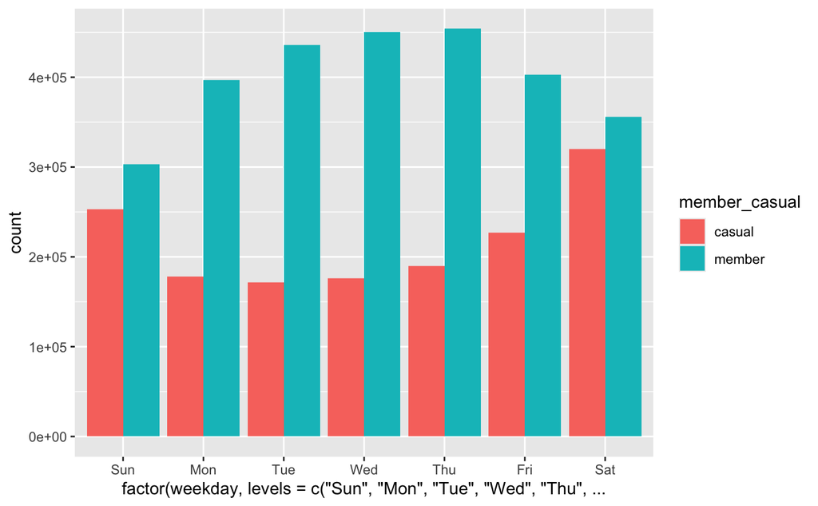

```r
ggplot(
  data = ride_data,
  mapping = aes(x = factor(weekday, levels=c('Sun', 'Mon', 'Tue', 'Wed', 'Thu', 'Fri', 'Sat')), fill = member_casual)
) + geom_bar(position = "dodge")
```

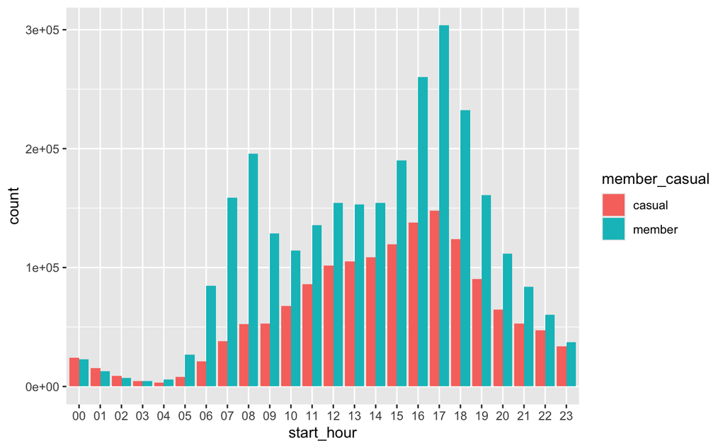

```r
ggplot(
  data = ride_data,
  mapping = aes(x = start_hour, fill = member_casual)
) + geom_bar(position = "dodge")
```

We can see that for both members and casual riders there are more rides registered during warmer months, June - September. However, during colder months while there are less riders, members still utilize Cyclistic services proportionally more than casual riders. This makes sense if members use Cyclistic to commute to work. We can also see that members use Cyclistic the most on Thursdays while casual riders use Cyclistic the most on Saturdays which we saw when looking at the mode earlier. However we get additional information from the above graph which shows us that members have the most usage on Wednesday - Thursday, with the lowest usage being on the weekend, the opposite of casual riders.

Now let us look at the average ride time.

```r
avg_time_weekday <- aggregate( ride_time ~ weekday + member_casual, ride_data , mean )

avg_time_weekday
```

| weekday | member_casual | ride_time |
| --- | --- | --- |
| Fri | casual | 1371.7658 |
| Mon | casual | 1394.6630 |
| Sat | casual | 1600.7706 |
| Sun | casual | 1635.8794 |
| Thu | casual | 1207.6851 |
| Tue | casual | 1253.0661 |
| Wed | casual | 1219.6544 |
| Fri | member | 733.8833 |
| Mon | member | 715.9235 |
| Sat | member | 838.7726 |

[output cut: 4 more lines]

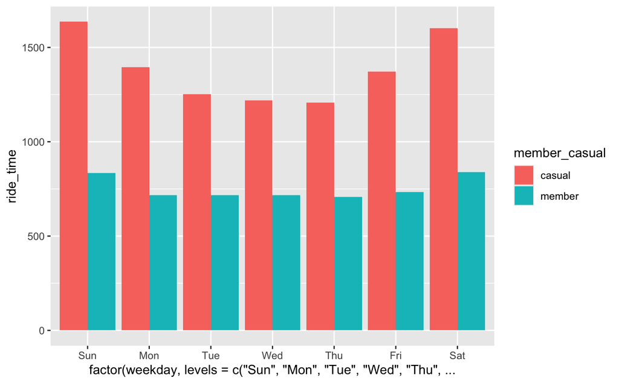

```r
ggplot(
  data = avg_time_weekday,
  mapping = aes(x = factor(weekday, levels=c('Sun', 'Mon', 'Tue', 'Wed', 'Thu', 'Fri', 'Sat')), y = ride_time, fill = member_casual)
) + geom_bar(stat='identity', position = "dodge")
```

```r
avg_time_month <- aggregate( ride_time ~ month + member_casual, ride_data , mean )

avg_time_month
```

| month | member_casual | ride_time |
| --- | --- | --- |
| 01 | casual | 932.2414 |
| 02 | casual | 1189.5017 |
| 03 | casual | 1322.2046 |
| 04 | casual | 1486.5893 |
| 05 | casual | 1612.2406 |
| 06 | casual | 1444.5139 |
| 07 | casual | 1513.3892 |
| 08 | casual | 1461.9446 |
| 09 | casual | 1412.1750 |
| 10 | casual | 1283.0946 |

[output cut: 14 more lines]

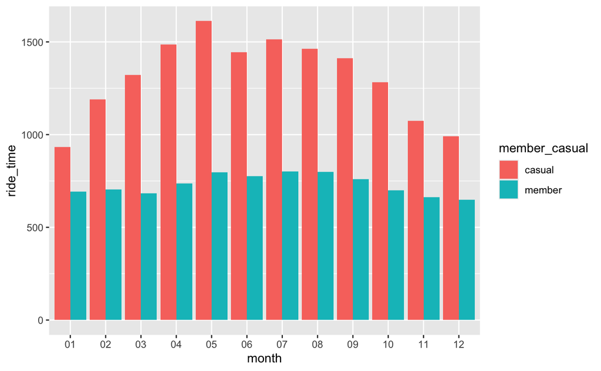

```r
ggplot(
  data = avg_time_month,
  mapping = aes(x = month, y = ride_time, fill = member_casual)
) + geom_bar(stat='identity', position = "dodge")
```